# First Year Project Beautiful

14-03-2023

# Packages

```r
library(tidyverse)
```

# Reading Data

```r
data <- read.csv("Factors Affecting Extinction.csv")
head(data)
```

```
##          Species Time Pairs Size Status
## 1    Sparrowhawk 3.03  1.00    L      R
## 2        Buzzard 5.46  2.00    L      R
## 3        Kestrel 4.10  1.21    L      R
## 4      Peregrine 1.68  1.13    L      R
## 5 Grey_partridge 8.85  5.17    L      R
## 6          Quail 1.49  1.00    L      M
```

We have the species, which is our identifier of each bird. Time (extinction time) is a numerical value, as is Paris (nesting pairs). Both size and status are categorical variables with either [L (Large),S (Small)] or [R (Resident),M (Migrant)]

# Making a full model

We make a full model describing extinction time (outcome variable) as a combination of pairs, size and status (predictor variables) The model will look like this:
$$\hat{Y} = \hat{\beta_0} + \hat{\beta_1} \times \text{Pairs} +
\hat{\beta_2} \times \text{Size} + \hat{\beta_3} \times \text{Status} +
\hat{\beta_4} \times \text{Pairs} \times \text{Size} + \hat{\beta_5}
\times \text{Pairs} \times \text{Status} + \hat{\beta_6} \times
\text{Status} \times \text{Size} + \hat{\beta_7} \times \text{Pairs}
\times \text{Size} \times \text{Status}$$

```r
lm_full <- lm(formula = Time ~ Pairs + Size + Status + Pairs*Size + Pairs * Status + Size*Status + Pairs*Size*Status, data)
summary(lm_full)
```

```
##
## Call:
## lm(formula = Time ~ Pairs + Size + Status + Pairs * Size + Pairs *
##     Status + Size * Status + Pairs * Size * Status, data = data)
##
## Residuals:
##     Min      1Q  Median      3Q     Max
## -14.769  -3.644  -0.652   1.128  49.831
##
## Coefficients:
##                     Estimate Std. Error t value Pr(>|t|)
## (Intercept)           0.7775     6.6831   0.116    0.908
## Pairs                 1.2397     1.7232   0.719    0.475
## SizeS                 0.1759     8.3168   0.021    0.983
## StatusR               4.0489     7.8704   0.514    0.609
## Pairs:SizeS          -0.9058     2.4206  -0.374    0.710
## Pairs:StatusR         0.5317     2.0037   0.265    0.792
## SizeS:StatusR        -9.4013     9.8736  -0.952    0.345
## Pairs:SizeS:StatusR   2.0047     2.7218   0.737    0.465
##
## Residual standard error: 9.237 on 54 degrees of freedom
## Multiple R-squared:  0.3398, Adjusted R-squared:  0.2542
## F-statistic:  3.97 on 7 and 54 DF,  p-value: 0.001446
```

```r
lm_full2 <- lm(formula = Time ~ Pairs*Size*Status, data)
summary(lm_full2)
```

```
##
## Call:
## lm(formula = Time ~ Pairs * Size * Status, data = data)
##
## Residuals:
##     Min      1Q  Median      3Q     Max
## -14.769  -3.644  -0.652   1.128  49.831
##
## Coefficients:
##                     Estimate Std. Error t value Pr(>|t|)
## (Intercept)           0.7775     6.6831   0.116    0.908
## Pairs                 1.2397     1.7232   0.719    0.475
## SizeS                 0.1759     8.3168   0.021    0.983
## StatusR               4.0489     7.8704   0.514    0.609
## Pairs:SizeS          -0.9058     2.4206  -0.374    0.710
## Pairs:StatusR         0.5317     2.0037   0.265    0.792
## SizeS:StatusR        -9.4013     9.8736  -0.952    0.345
## Pairs:SizeS:StatusR   2.0047     2.7218   0.737    0.465
##
## Residual standard error: 9.237 on 54 degrees of freedom
## Multiple R-squared:  0.3398, Adjusted R-squared:  0.2542
## F-statistic:  3.97 on 7 and 54 DF,  p-value: 0.001446
```

Calling the summary on the Multiple linear model we just created, we get different measurements. Looking at the R-squared, we got a R-Squared value of 0.3398. We also get an adjusted R-squared with a value of 0.2542. Both show a weak correlation of predictor variables and outcome variables. The p-value is 0.0014 which means this data would occur randomly, approximately 1.4% of the time. Looking at the summary we see that R has encoded the Size value “Small” as 1, and Status value “Resident” as one. The opposite values are encoded to 0. This gives us four different possible model looks:

The first model is where Size = Small and Status = Resident. This model is the same as proposed earlier.
$$\hat{Y} = \hat{\beta_0} +
\hat{\beta_1} \times \text{Pairs} +
\hat{\beta_2} \times \text{Size} +
\hat{\beta_3} \times \text{Status} +
\hat{\beta_4} \times \text{Pairs} \times \text{Size} +
\hat{\beta_5} \times \text{Pairs} \times \text{Status} +
\hat{\beta_6} \times \text{Status} \times \text{Size} +
\hat{\beta_7} \times \text{Pairs} \times \text{Size} \times
\text{Status}$$
The second model is the model where Size = Large and Status = Resident. In this model, all Size variabels are encoded to 0, meaning terms including Size are eliminated.

$$\hat{Y} = \hat{\beta_0} +
\hat{\beta_1} \times \text{Pairs} +
\hat{\beta_3} \times \text{Status} +
\hat{\beta_5} \times \text{Pairs} \times \text{Status}$$
The third model is where Size = Large and Status = Migrant. Both Status and Size are 0.

$$\hat{Y} = \hat{\beta_0} +
\hat{\beta_1} \times \text{Pairs}$$
The fourth model is where Size = Small and Status = Migrant. Migrant is eliminated from terms including it.
$$\hat{Y} = \hat{\beta_0} +
\hat{\beta_1} \times \text{Pairs} +
\hat{\beta_2} \times \text{Size} +
\hat{\beta_4} \times \text{Pairs} \times \text{Size}$$

For the next step in the analysis of the dataset, we look at outliers and residuals

## I would say 4 regression lines? it is still the same model, not 4 different models.

## Not only equation but solve with our beta and plot the 4 regression lines? analyze contribution of it variable. (part of #6)

Analyzing assumptions of linear regression

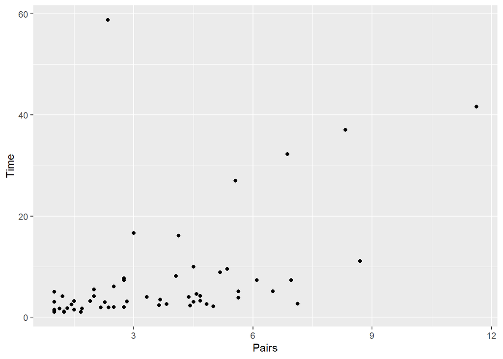

```r
ggplot(data, aes(Pairs, Time)) + geom_point()
```

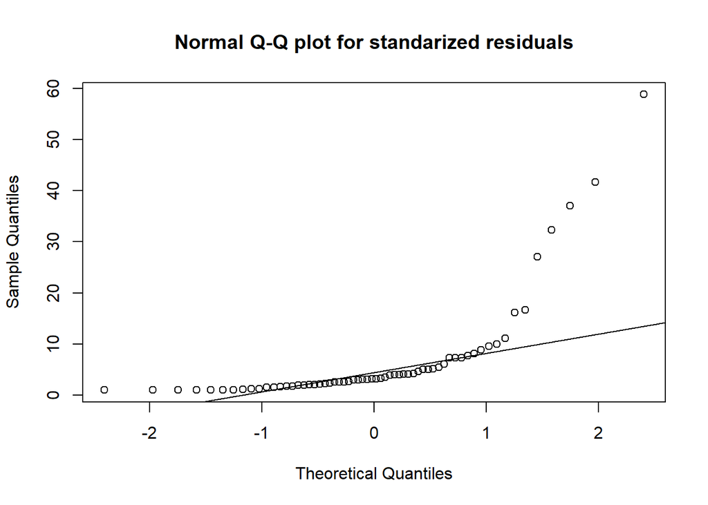

```r
qqnorm(data$Time, main="Normal Q-Q plot for standarized residuals")
qqline(data$Time)
```

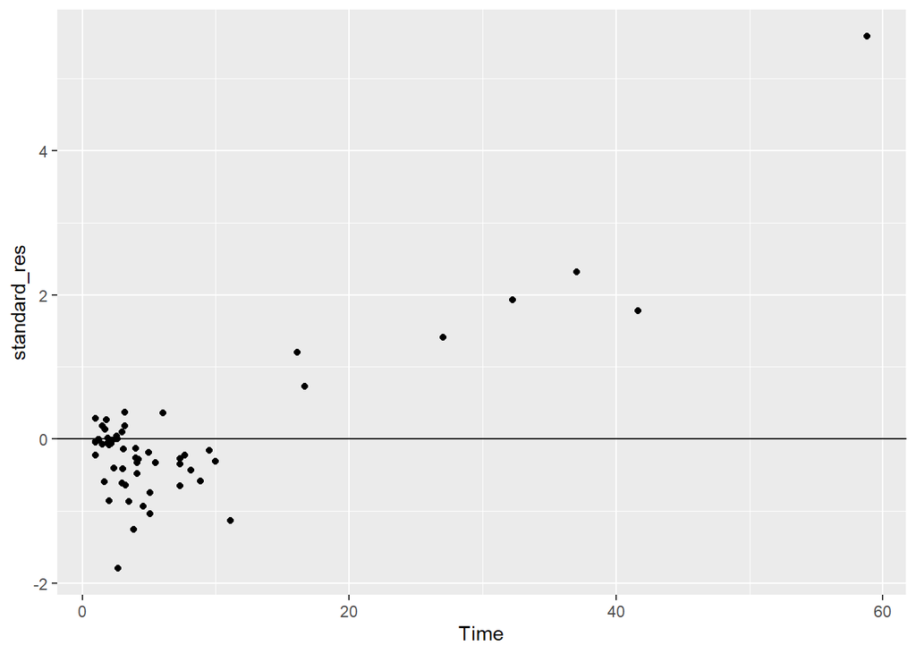

```r
standard_res <- rstandard(lm_full)
final_data <- cbind(data, standard_res)
ggplot(final_data) + geom_point(aes(Time, standard_res)) + geom_abline(slope = 0)
```

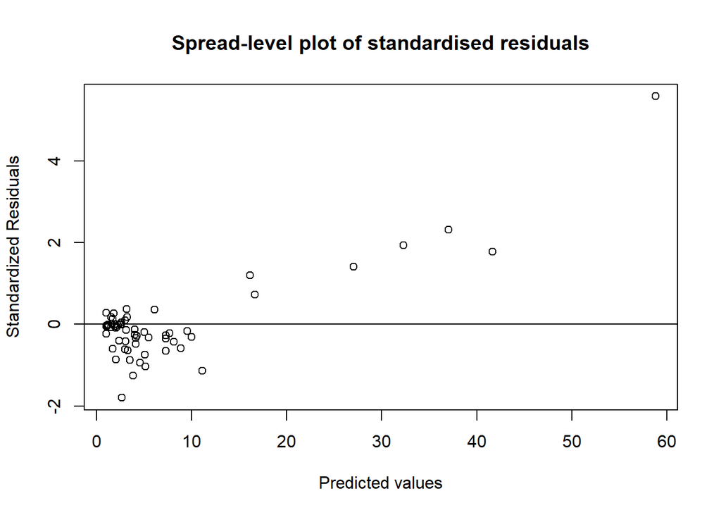

```r
plot((final_data$Time), standard_res, ylab='Standardized Residuals', xlab='Predicted values', main="Spread-level plot of standardised residuals")
abline(0, 0)
```

1. Normality. Q-Q plot shows big deviations on each side. Pag 60
2. Homoscedasticity and linearity. Spread-level plot. Shows a clear non-linear pattern.

Transformations of variables

###### R2, q-q plot and spead-level plot for each transformation of the outcome ‘Time’

```r
lm_full <- lm(formula = Time ~ Pairs + Size + Status + Pairs*Size + Pairs*Status + Size*Status + Pairs*Size*Status, data)
lm_full.log <- lm(formula = log(Time) ~ Pairs + Size + Status + Pairs*Size + Pairs * Status + Size*Status + Pairs*Size*Status, data)
lm_full.sqrt <- lm(formula = sqrt(Time) ~ Pairs + Size + Status + Pairs*Size + Pairs * Status + Size*Status + Pairs*Size*Status, data)
lm_full.inverse <- lm(formula = 1/Time ~ Pairs + Size + Status + Pairs*Size + Pairs * Status + Size*Status + Pairs*Size*Status, data)

summary(lm_full)$adj.r.squared
```

```
## [1] 0.2542168
```

```r
summary(lm_full.log)$adj.r.squared
```

```
## [1] 0.5783079
```

```r
summary(lm_full.sqrt)$adj.r.squared
```

```
## [1] 0.4198745
```

```r
summary(lm_full.inverse)$adj.r.squared
```

```
## [1] 0.6264888
```

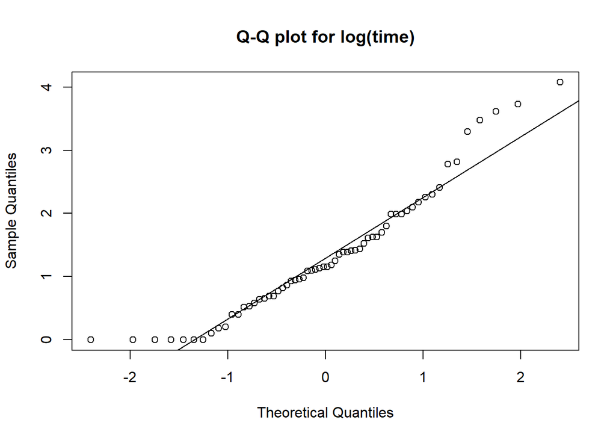

```r
qqnorm(log(data$Time),main="Q-Q plot for log(time)")
qqline(log(data$Time))
```

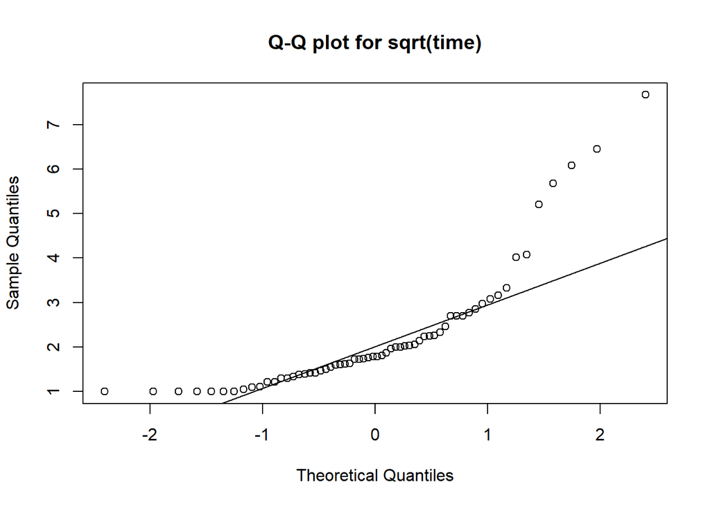

```r
qqnorm(sqrt(data$Time),main="Q-Q plot for sqrt(time)")
qqline(sqrt(data$Time))
```

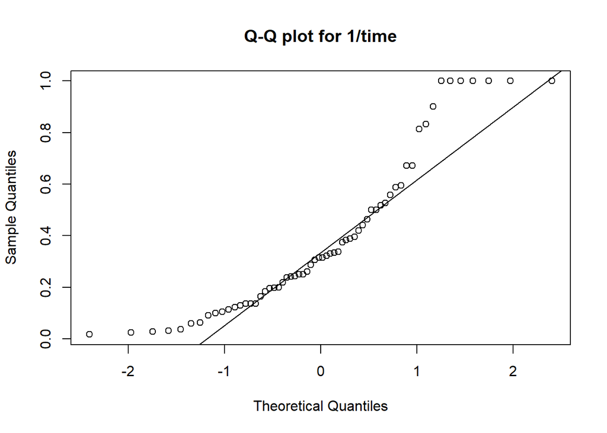

```r
qqnorm(1/(data$Time),main="Q-Q plot for 1/time")
qqline(1/(data$Time))
```

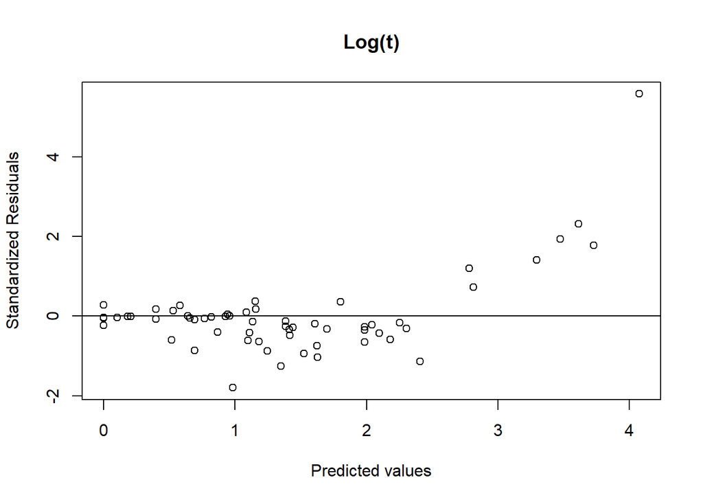

```r
plot(log(final_data$Time), standard_res, ylab='Standardized Residuals', xlab='Predicted values', main="Log(t)")
abline(0, 0)
```

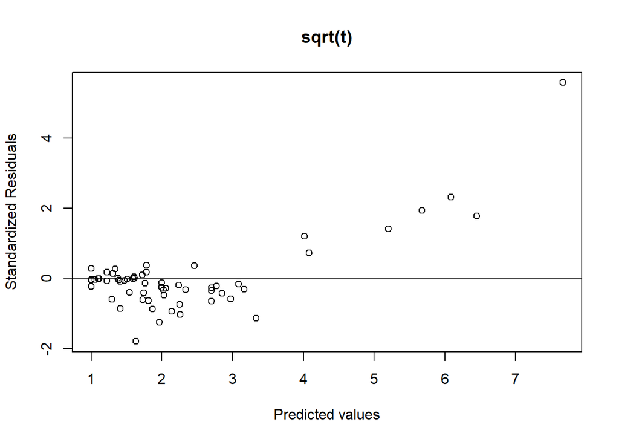

```r
plot(sqrt(final_data$Time), standard_res, ylab='Standardized Residuals', xlab='Predicted values', main = "sqrt(t)")
abline(0, 0)
```

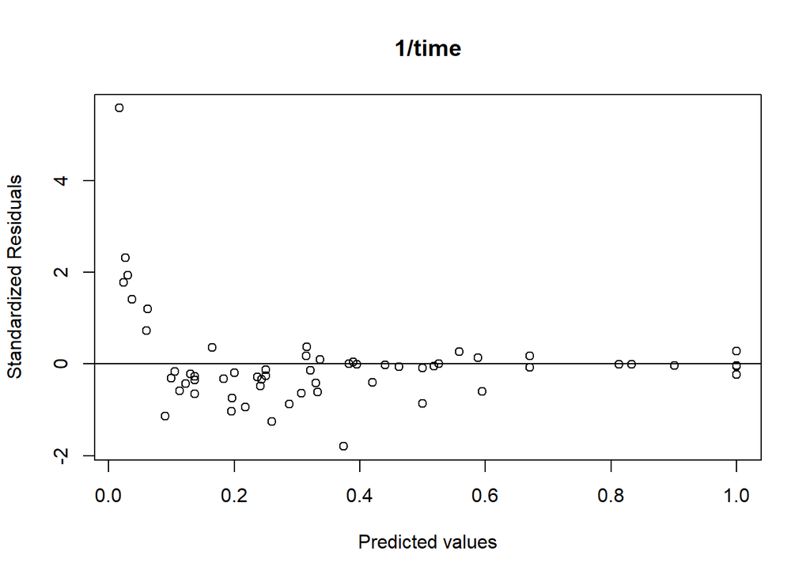

```r
plot(1/(final_data$Time), standard_res, ylab='Standardized Residuals', xlab='Predicted values', main="1/time")
abline(0, 0)
```

We decided to keep working with the transformed variable log(Time). New model:

```r
lm_full_transformed <- lm(formula = log(Time) ~ Pairs + Size + Status + Pairs*Size + Pairs * Status + Size*Status + Pairs*Size*Status, data)
summary(lm_full_transformed)$adj.r.squared
```

```
## [1] 0.5783079
```

```r
lm_full_inverse <- lm(formula = 1/(Time) ~ Pairs + Size + Status + Pairs*Size + Pairs * Status + Size*Status + Pairs*Size*Status, data)
summary(lm_full_inverse)$adj.r.squared
```

```
## [1] 0.6264888
```

#Outliers

```r
ckd_inv <- cooks.distance(lm_full_inverse)
ckd_log <- cooks.distance(lm_full_transformed)

#sub_ckd <- subset(ckd_inv, ckd_ inv< 0.2)

index <- which(ckd_inv > 0.2)
index.log <- which(ckd_log > 0.2)

index
```

```
## 13 14 60
## 13 14 60
```

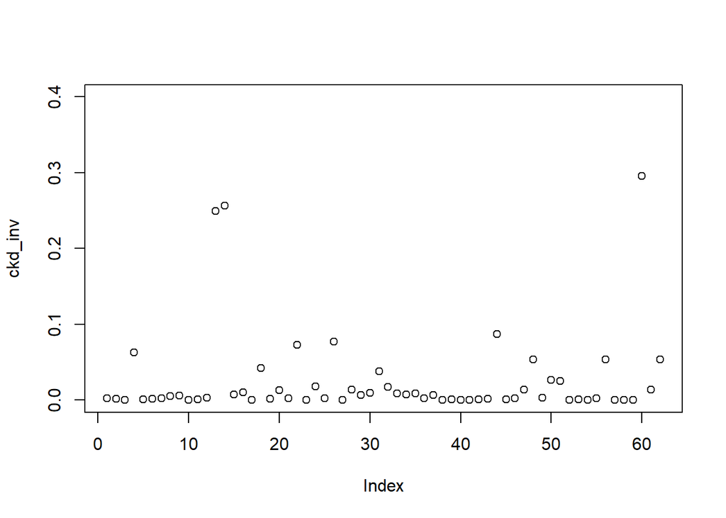

```r
plot(ckd_inv, ylim = c(0,0.4))
```

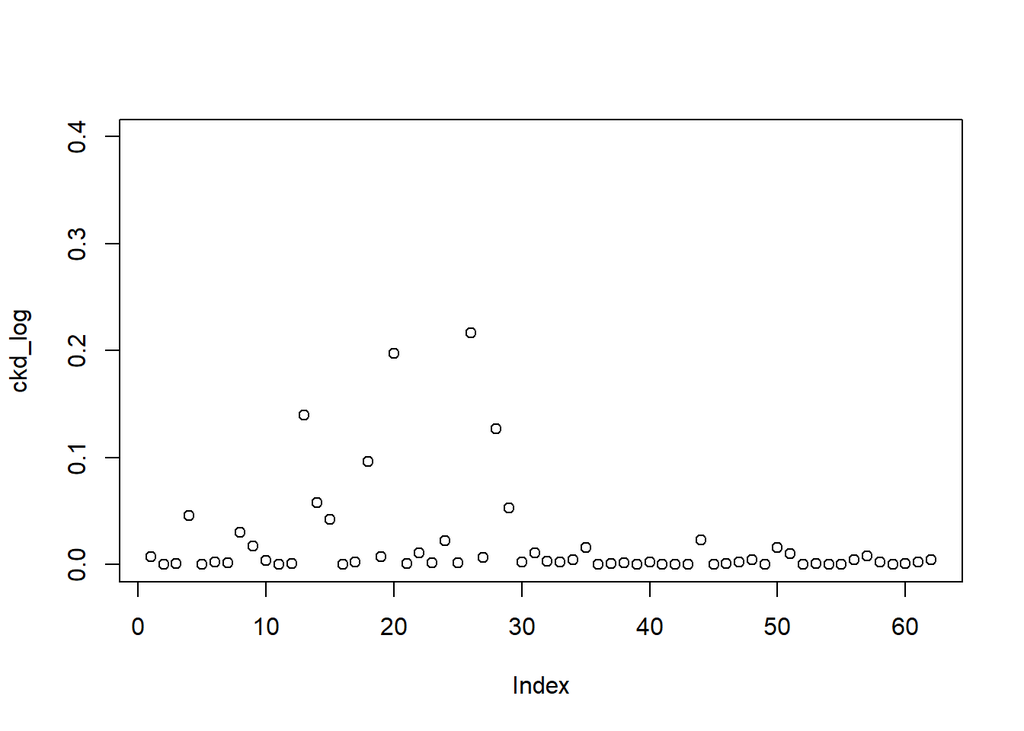

```r
plot(ckd_log, ylim = c(0,0.4))
```

```r
#plot(sub_ckd, ylim = c(0,0.15))
```

????? in log transf non of them is significantly bigger than the others

If we remove three outliers in inverse………

```r
data_ckd <- data[-c(index),]
data_ckd_log <- data[-c(index.log),]

lm_full_inverse_ckd <- lm(formula = 1/(Time) ~ Pairs + Size + Status + Pairs*Size + Pairs*Status + Size*Status + Pairs*Size*Status, data_ckd)
#summary(lm_full_inverse_ckd)#$adj.r.squared
#summary(lm_full_inverse)#$adj.r.squared


lm_full_log_ckd <- lm(formula = log(Time) ~ Pairs + Size + Status + Pairs*Size + Pairs*Status + Size*Status + Pairs*Size*Status, data_ckd_log)
#summary(lm_full_log_ckd)#$adj.r.squared
#summary(lm_full_transformed)


summary(lm_full_inverse_ckd)$adj.r.squared
```

```
## [1] 0.6673142
```

```r
summary(lm_full_inverse)$adj.r.squared
```

```
## [1] 0.6264888
```

```r
summary(lm_full_log_ckd)$adj.r.squared
```

```
## [1] 0.6282088
```

```r
summary(lm_full_transformed)$adj.r.squared
```

```
## [1] 0.5783079
```

?????ludek outliers and logvsinverse

```r
m1 <- lm(formula = 1/(Time) ~ Pairs, data)
m2 <- lm(formula = 1/(Time) ~ Pairs + Size, data)
m3 <- lm(formula = 1/(Time) ~ Pairs + Size + Pairs*Size, data)
m4 <- lm(formula = 1/(Time) ~ Pairs + Status, data)
m5 <- lm(formula = 1/(Time) ~ Pairs + Status + Pairs * Status, data)
m6 <- lm(formula = 1/(Time) ~ Pairs + Size + Status, data)
m7 <- lm(formula = 1/(Time) ~ Pairs + Size + Status + Pairs*Size + Pairs*Status, data)
m8 <- lm(formula = 1/(Time) ~ Pairs + Size + Status + Pairs*Size + Pairs*Status + Pairs*Size*Status + Size*Status, data)
m9 <- lm(formula = 1/(Time) ~ Pairs + Pairs*Size*Status - Size*Status+Size + Status + Pairs*Size + Pairs*Status , data)


anova(m1, m2, m3, m4, m5, m6, m7, m8, m9)
```

```
## Analysis of Variance Table
##
## Model 1: 1/(Time) ~ Pairs
## Model 2: 1/(Time) ~ Pairs + Size
## Model 3: 1/(Time) ~ Pairs + Size + Pairs * Size
## Model 4: 1/(Time) ~ Pairs + Status
## Model 5: 1/(Time) ~ Pairs + Status + Pairs * Status
## Model 6: 1/(Time) ~ Pairs + Size + Status
## Model 7: 1/(Time) ~ Pairs + Size + Status + Pairs * Size + Pairs * Status
## Model 8: 1/(Time) ~ Pairs + Size + Status + Pairs * Size + Pairs * Status +
##     Pairs * Size * Status + Size * Status
## Model 9: 1/(Time) ~ Pairs + Pairs * Size * Status - Size * Status + Size +
##     Status + Pairs * Size + Pairs * Status
##   Res.Df    RSS Df Sum of Sq       F    Pr(>F)
## 1     60 3.3390
## 2     59 2.5615  1   0.77746 23.0232 1.304e-05 ***
## 3     58 2.3773  1   0.18419  5.4544  0.023264 *
## 4     59 2.9226 -1  -0.54521 16.1456  0.000183 ***
## 5     58 2.6467  1   0.27583  8.1683  0.006044 **
## 6     58 2.1852  0   0.46154
## 7     56 1.8526  2   0.33257  4.9243  0.010853 *
## 8     54 1.8235  2   0.02912  0.4311  0.651980
## 9     55 1.8517 -1  -0.02818  0.8344  0.365063
## ---
## Signif. codes:  0 '***' 0.001 '**' 0.01 '*' 0.05 '.' 0.1 ' ' 1
```

```r
summary(m1)$adj.r.squared
```

```
## [1] 0.3844603
```

```r
summary(m2)$adj.r.squared
```

```
## [1] 0.5197802
```

```r
summary(m3)$adj.r.squared
```

```
## [1] 0.5466262
```

```r
summary(m4)$adj.r.squared
```

```
## [1] 0.4520978
```

```r
summary(m5)$adj.r.squared
```

```
## [1] 0.495254
```

```r
summary(m6)$adj.r.squared
```

```
## [1] 0.5832723
```

```r
summary(m7)$adj.r.squared
```

```
## [1] 0.6340771
```

```r
summary(m8)$adj.r.squared
```

```
## [1] 0.6264888
```

```r
summary(m9)$adj.r.squared
```

```
## [1] 0.6276134
```

```r
summary(m7)
```

```
##
## Call:
## lm(formula = 1/(Time) ~ Pairs + Size + Status + Pairs * Size +
##     Pairs * Status, data = data)
##
## Residuals:
##      Min       1Q   Median       3Q      Max
## -0.46152 -0.09369 -0.01133  0.08777  0.48092
##
## Coefficients:
##               Estimate Std. Error t value Pr(>|t|)
## (Intercept)    0.67505    0.09678   6.975 3.80e-09 ***
## Pairs         -0.09340    0.02601  -3.591 0.000696 ***
## SizeS          0.37217    0.08732   4.262 7.84e-05 ***
## StatusR       -0.35078    0.09319  -3.764 0.000403 ***
## Pairs:SizeS   -0.04936    0.02155  -2.290 0.025786 *
## Pairs:StatusR  0.06355    0.02614   2.432 0.018258 *
## ---
## Signif. codes:  0 '***' 0.001 '**' 0.01 '*' 0.05 '.' 0.1 ' ' 1
##
## Residual standard error: 0.1819 on 56 degrees of freedom
## Multiple R-squared:  0.6641, Adjusted R-squared:  0.6341
## F-statistic: 22.14 on 5 and 56 DF,  p-value: 3.59e-12
```